# Primer Documento

Isaac Zainea

2024-09-12

## Primer trabajo

```r
#Hola mundo, yo si soy un comentario, un simple
#texto asignado a nada


library(readr)
titanic <- read.csv("Datos/titanic.csv")

summary(titanic)
```

```
##   PassengerId       Survived          Pclass          Name
##  Min.   :  1.0   Min.   :0.0000   Min.   :1.000   Length:891
##  1st Qu.:223.5   1st Qu.:0.0000   1st Qu.:2.000   Class :character
##  Median :446.0   Median :0.0000   Median :3.000   Mode  :character
##  Mean   :446.0   Mean   :0.3838   Mean   :2.309
##  3rd Qu.:668.5   3rd Qu.:1.0000   3rd Qu.:3.000
##  Max.   :891.0   Max.   :1.0000   Max.   :3.000
##
##      Sex                 Age            SibSp           Parch
##  Length:891         Min.   : 0.42   Min.   :0.000   Min.   :0.0000
##  Class :character   1st Qu.:20.12   1st Qu.:0.000   1st Qu.:0.0000
##  Mode  :character   Median :28.00   Median :0.000   Median :0.0000
##                     Mean   :29.70   Mean   :0.523   Mean   :0.3816
##                     3rd Qu.:38.00   3rd Qu.:1.000   3rd Qu.:0.0000
##                     Max.   :80.00   Max.   :8.000   Max.   :6.0000
##                     NA's   :177
##     Ticket               Fare           Cabin             Embarked
##  Length:891         Min.   :  0.00   Length:891         Length:891
##  Class :character   1st Qu.:  7.91   Class :character   Class :character
##  Mode  :character   Median : 14.45   Mode  :character   Mode  :character
##                     Mean   : 32.20
##                     3rd Qu.: 31.00
##                     Max.   :512.33
##
```

En el anterior vimos que `summary` hace un resumen de lo que hay en el dataframe.

Por otro lado, si queremos ver la dimensión de los datos usamos:

```r
dim(titanic)
```

```
## [1] 891  12
```

Si quiero inspeccionar las primera filas usamos:

```r
head(titanic)
```

```
##   PassengerId Survived Pclass
## 1           1        0      3
## 2           2        1      1
## 3           3        1      3
## 4           4        1      1
## 5           5        0      3
## 6           6        0      3
##                                                  Name    Sex Age SibSp Parch
## 1                             Braund, Mr. Owen Harris   male  22     1     0
## 2 Cumings, Mrs. John Bradley (Florence Briggs Thayer) female  38     1     0
## 3                              Heikkinen, Miss. Laina female  26     0     0
## 4        Futrelle, Mrs. Jacques Heath (Lily May Peel) female  35     1     0
## 5                            Allen, Mr. William Henry   male  35     0     0
## 6                                    Moran, Mr. James   male  NA     0     0
##             Ticket    Fare Cabin Embarked
## 1        A/5 21171  7.2500              S
## 2         PC 17599 71.2833   C85        C
## 3 STON/O2. 3101282  7.9250              S
## 4           113803 53.1000  C123        S
## 5           373450  8.0500              S
## 6           330877  8.4583              Q
```

Quiero aplicar una función en cada columna, uso `sapply` que aquí la vermos en acción identificando cada clase de cada columna:

```r
sapply(titanic,class)
```

```
## PassengerId    Survived      Pclass        Name         Sex         Age
##   "integer"   "integer"   "integer" "character" "character"   "numeric"
##       SibSp       Parch      Ticket        Fare       Cabin    Embarked
##   "integer"   "integer" "character"   "numeric" "character" "character"
```

A continuación, te presento un ejemplo básico de cómo sería una clase de **data wrangling** en **R** escrita en **RMarkdown**. Puedes copiar este contenido en un archivo con extensión `.Rmd` y luego abrirlo en **RStudio** para ejecutarlo.

## 3. Selección y Filtrado de Datos

### 3.1 Selección de columnas

```r
# Seleccionar columnas específicas
titanic_subset <- titanic[, c("Name", "Sex", "Age", "Survived")]
head(titanic_subset)
```

```
##                                                  Name    Sex Age Survived
## 1                             Braund, Mr. Owen Harris   male  22        0
## 2 Cumings, Mrs. John Bradley (Florence Briggs Thayer) female  38        1
## 3                              Heikkinen, Miss. Laina female  26        1
## 4        Futrelle, Mrs. Jacques Heath (Lily May Peel) female  35        1
## 5                            Allen, Mr. William Henry   male  35        0
## 6                                    Moran, Mr. James   male  NA        0
```

### 3.2 Filtrado de filas

```r
# Filtrar las filas donde la edad es mayor a 30
titanic_adultos <- titanic[titanic$Age > 30, ]
head(titanic_adultos)
```

```
##    PassengerId Survived Pclass
## 2            2        1      1
## 4            4        1      1
## 5            5        0      3
## NA          NA       NA     NA
## 7            7        0      1
## 12          12        1      1
##                                                   Name    Sex Age SibSp Parch
## 2  Cumings, Mrs. John Bradley (Florence Briggs Thayer) female  38     1     0
## 4         Futrelle, Mrs. Jacques Heath (Lily May Peel) female  35     1     0
## 5                             Allen, Mr. William Henry   male  35     0     0
## NA                                                <NA>   <NA>  NA    NA    NA
## 7                              McCarthy, Mr. Timothy J   male  54     0     0
## 12                            Bonnell, Miss. Elizabeth female  58     0     0
##      Ticket    Fare Cabin Embarked
## 2  PC 17599 71.2833   C85        C
## 4    113803 53.1000  C123        S
## 5    373450  8.0500              S
## NA     <NA>      NA  <NA>     <NA>
## 7     17463 51.8625   E46        S
## 12   113783 26.5500  C103        S
```

## 4. Manipulación de Datos

### 4.1 Crear nuevas columnas

```r
# Crear una nueva columna que indica si el pasajero era un adulto
titanic$Adulto <- ifelse(titanic$Age >= 18, "Sí", "No")
head(titanic)
```

```
##   PassengerId Survived Pclass
## 1           1        0      3
## 2           2        1      1
## 3           3        1      3
## 4           4        1      1
## 5           5        0      3
## 6           6        0      3
##                                                  Name    Sex Age SibSp Parch
## 1                             Braund, Mr. Owen Harris   male  22     1     0
## 2 Cumings, Mrs. John Bradley (Florence Briggs Thayer) female  38     1     0
## 3                              Heikkinen, Miss. Laina female  26     0     0
## 4        Futrelle, Mrs. Jacques Heath (Lily May Peel) female  35     1     0
## 5                            Allen, Mr. William Henry   male  35     0     0
## 6                                    Moran, Mr. James   male  NA     0     0
##             Ticket    Fare Cabin Embarked Adulto
## 1        A/5 21171  7.2500              S     Sí
## 2         PC 17599 71.2833   C85        C     Sí
## 3 STON/O2. 3101282  7.9250              S     Sí
## 4           113803 53.1000  C123        S     Sí
## 5           373450  8.0500              S     Sí
## 6           330877  8.4583              Q   <NA>
```

### 4.2 Agrupación y resumen

```r
# Instalar y cargar el paquete dplyr
library(dplyr)
# Agrupar por sexo y calcular el promedio de edad
resumen_sexo <- titanic %>%
  group_by(Sex) %>%
  summarise(promedio_edad = mean(Age, na.rm = TRUE))
resumen_sexo
```

```
## # A tibble: 2 × 2
##   Sex    promedio_edad
##   <chr>          <dbl>
## 1 female          27.9
## 2 male            30.7
```

## 5. Limpieza de Datos

### 5.1 Manejo de valores faltantes (NA)

```r
# Contar valores faltantes en cada columna
colSums(is.na(titanic))
```

```
## PassengerId    Survived      Pclass        Name         Sex         Age
##           0           0           0           0           0         177
##       SibSp       Parch      Ticket        Fare       Cabin    Embarked
##           0           0           0           0           0           0
##      Adulto
##         177
```

```r
# Reemplazar los valores faltantes en la columna 'Age' con la media
titanic$Age[is.na(titanic$Age)] <- mean(titanic$Age, na.rm = TRUE)
```

## 6. Guardar Datos

### 6.1 Guardar un archivo CSV

```r
# Guardar los datos manipulados en un nuevo archivo CSV
write.csv(titanic, "Datos/titanic_modificado.csv", row.names = FALSE)
```

## Plot de AGE

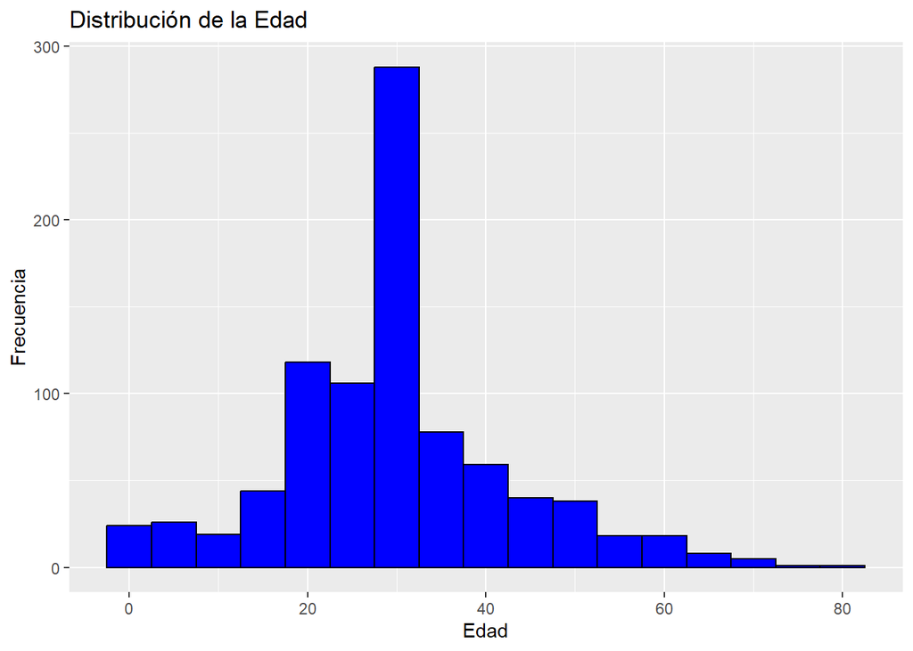

```r
library(ggplot2)


# 2. Visualizaciones con ggplot2

# a. Histograma de la variable edad
ggplot(titanic, aes(x = Age)) +
  geom_histogram(binwidth = 5, fill = "blue", color = "black") +
  labs(title = "Distribución de la Edad", x = "Edad", y = "Frecuencia")
```

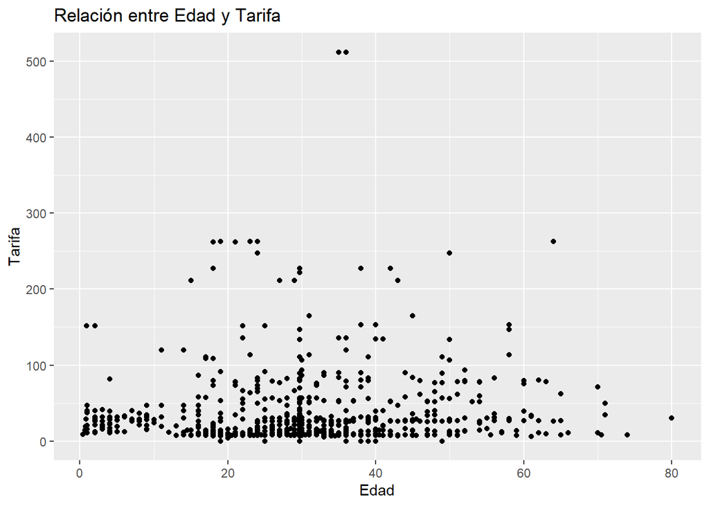

```r
## Camel Case (miVariable)
## Pascal Case (MiVariable)
## Snake Case (mi_variable)


# a. Gráfico de dispersión entre edad y tarifa
ggplot(titanic, aes(x = Age, y = Fare)) +
  geom_point() +
  labs(title = "Relación entre Edad y Tarifa",
       x = "Edad",
       y = "Tarifa")
```

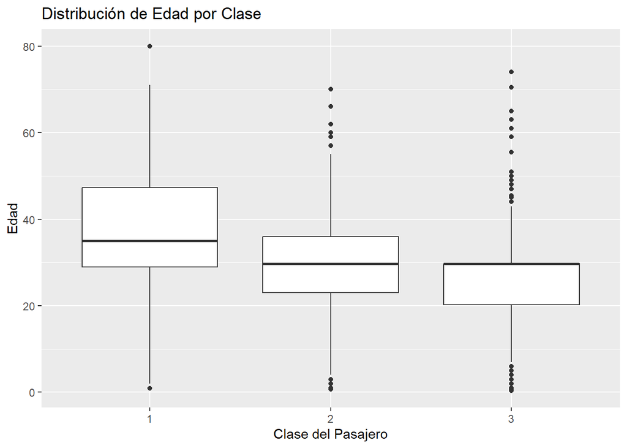

```r
# c. Boxplot de la edad por clase de pasajero
ggplot(titanic, aes(x = as.factor(Pclass), y = Age)) +
  geom_boxplot() +
  labs(title = "Distribución de Edad por Clase",
       x = "Clase del Pasajero",
       y = "Edad")
```

## Conclusión

### ¿Cómo usar este archivo?

1. Crea un archivo con extensión `.Rmd` en **RStudio**.
2. Copia y pega el código anterior en el archivo.
3. Guarda el archivo.
4. Puedes hacer clic en **Knit** para generar un reporte en formato HTML con el contenido de la clase.